# Open and plot shapefiles

Starting with this episode, we will be moving from working with raster data to working with vector data. In this episode, we will open and plot point, line and polygon vector data stored in shapefile format in R. These data refer to the [NEON Harvard Forest field site](https://www.neonscience.org/field-sites/field-sites-map/HARV), which we have been working with in previous episodes. In later episodes, we will learn how to work with raster and vector data together and combine them into a single plot.

**Objectives**

- Know the difference between point, line, and polygon vector elements.
- Load point, line, and polygon shapefiles into R.
- Access the attributes of a spatial object in R.

**Keypoints**

- Shapefile metadata include geometry type, CRS, and extent.
- Load spatial objects into R with the `st_read()` function.
- Spatial objects can be plotted directly with `ggplot` using the `geom_sf()` function. No need to convert to a dataframe.

If you’re just opening up this project, you’ll have to load the packages and data used in previous episodes.

```r
# load packages
library(raster)
library(rgdal)
library(ggplot2)
library(dplyr)


# data loaded from earlier episode
# DSM data for Harvard Forest
dsm <- raster("data/raster/HARV_dsmCrop.tif")
dsm_df <- as.data.frame(dsm, xy = TRUE)
```

# Import Shapefiles

We will use the `sf` package to work with vector data in R. Notice that the `rgdal` package automatically loads when `sf` is loaded. We will also use the `raster` package, which has been loaded in previous episodes, so we can explore raster and vector spatial metadata using similar commands. Make sure you have the `sf` library loaded.

```r
library(sf)
```

The shapefiles that we will import are:

- A polygon shapefile representing our field site boundary,
- A line shapefile representing roads, and
- A point shapefile representing the location of the [Fisher flux tower](https://www.neonscience.org/data-collection/flux-tower-measurements) located at the [NEON Harvard Forest field site](https://www.neonscience.org/field-sites/field-sites-map/HARV).

The first shapefile that we will open contains the boundary of our study area (or our Area Of Interest or AOI, hence the name `aoiBoundary`). To import shapefiles we use the `sf` function `st_read()`. `st_read()` requires the file path to the shapefile.

Let’s import our AOI:

```r
# use st_read function to open shapefile - only need to open .shp file
aoi_boundary <- st_read("data/vector/HarClip_UTMZ18.shp")
```

# Shapefile Metadata & Attributes

When we import the `HarClip_UTMZ18` shapefile layer into R (as our `aoi_boundary_HARV` object), the `st_read()` function automatically stores information about the data. We are particularly interested in the geospatial metadata, describing the format, CRS, extent, and other components of the vector data, and the attributes which describe properties associated with each individual vector object.

Key metadata for all shapefiles include:

1. **Object Type:** the class of the imported object.
2. **Coordinate Reference System (CRS):** the projection of the data.
3. **Extent:** the spatial extent (i.e. geographic area that the shapefile covers) of the shapefile. Note that the spatial extent for a shapefile represents the combined extent for all spatial objects in the shapefile.

We can view shapefile metadata using the `st_geometry_type()`, `st_crs()` and `st_bbox()` functions. First, let’s view the geometry type for our AOI shapefile:

```r
# view geometry type
st_geometry_type(aoi_boundary)
```

```
## [1] POLYGON
## 18 Levels: GEOMETRY POINT LINESTRING POLYGON MULTIPOINT ... TRIANGLE
```

Our `aoi_boundary_HARV` is a polygon object. The 18 levels shown below our output list the possible categories of the geometry type. Now let’s check what CRS this file data is in:

```r
# view coordinate reference system
st_crs(aoi_boundary)
```

```
## Coordinate Reference System:
##   User input: WGS 84 / UTM zone 18N
##   wkt:
## PROJCRS["WGS 84 / UTM zone 18N",
##     BASEGEOGCRS["WGS 84",
##         DATUM["World Geodetic System 1984",
##             ELLIPSOID["WGS 84",6378137,298.257223563,
##                 LENGTHUNIT["metre",1]]],
##         PRIMEM["Greenwich",0,
##             ANGLEUNIT["degree",0.0174532925199433]],
##         ID["EPSG",4326]],
##     CONVERSION["UTM zone 18N",
##         METHOD["Transverse Mercator",
##             ID["EPSG",9807]],
##         PARAMETER["Latitude of natural origin",0,
##             ANGLEUNIT["Degree",0.0174532925199433],
##             ID["EPSG",8801]],
##         PARAMETER["Longitude of natural origin",-75,
##             ANGLEUNIT["Degree",0.0174532925199433],
##             ID["EPSG",8802]],
##         PARAMETER["Scale factor at natural origin",0.9996,
##             SCALEUNIT["unity",1],
##             ID["EPSG",8805]],
##         PARAMETER["False easting",500000,
##             LENGTHUNIT["metre",1],
##             ID["EPSG",8806]],
##         PARAMETER["False northing",0,
##             LENGTHUNIT["metre",1],
##             ID["EPSG",8807]]],
##     CS[Cartesian,2],
##         AXIS["(E)",east,
##             ORDER[1],
##             LENGTHUNIT["metre",1]],
##         AXIS["(N)",north,
##             ORDER[2],
##             LENGTHUNIT["metre",1]],
##     ID["EPSG",32618]]
```

Our data in the CRS **UTM zone 18N**. The CRS is critical to interpreting the object’s extent values as it specifies units. To find the extent of our AOI, we can use the `st_bbox()` function:

```r
# view extent using the bounding box function
st_bbox(aoi_boundary)
```

```
##      xmin      ymin      xmax      ymax
##  732128.0 4713208.7  732251.1 4713359.2
```

Lastly, we can view all of the metadata and attributes for this shapefile object by printing it to the screen:

```r
# look at all information
aoi_boundary
```

```
## Simple feature collection with 1 feature and 1 field
## Geometry type: POLYGON
## Dimension:     XY
## Bounding box:  xmin: 732128 ymin: 4713209 xmax: 732251.1 ymax: 4713359
## Projected CRS: WGS 84 / UTM zone 18N
##   id                       geometry
## 1  1 POLYGON ((732128 4713359, 7...
```

# Plot a Shapefile

Next, let’s visualize the data in our `sf` object using the `ggplot` package. Unlike with raster data, we do not need to convert vector data to a dataframe before plotting with `ggplot`.

We’re going to customize our boundary plot by setting the size, color, and fill for our plot. When plotting `sf` objects with `ggplot2`, you need to use the `coord_sf()` coordinate system.

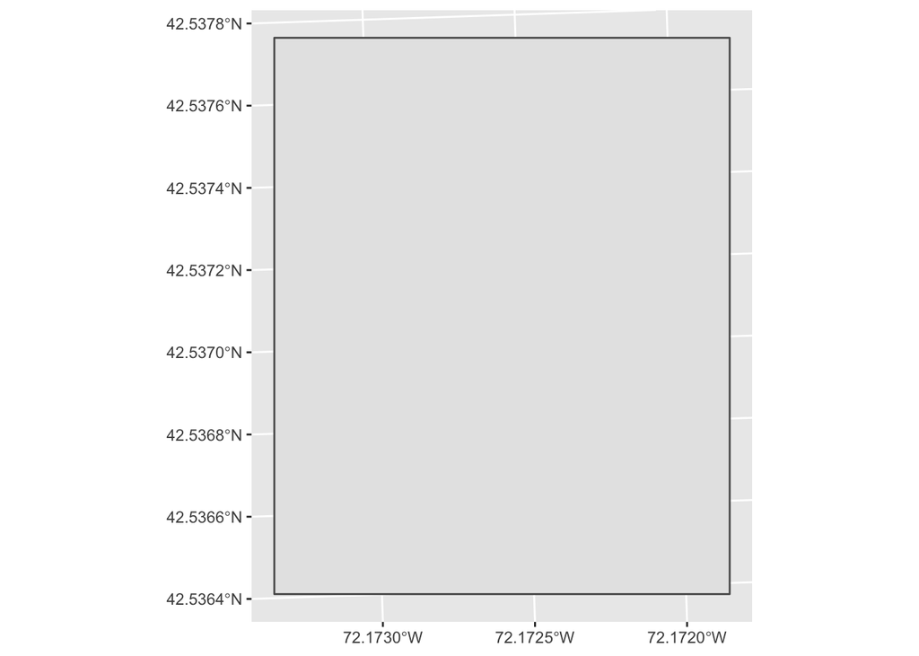

```r
# plot area of interest polygon
ggplot() +
  geom_sf(data = aoi_boundary) +
  coord_sf()
```

We can use ggplot to edit the style of how this polygon is plotted. We can change the fill, the line color and size, and add a title.

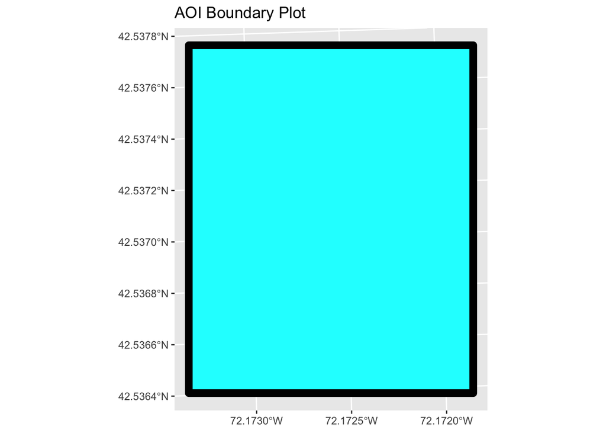

```r
# plot area of interest polygon and change style
ggplot() +
  geom_sf(data = aoi_boundary, size = 3, color = "black", fill = "cyan1") +
  ggtitle("AOI Boundary Plot") +
  coord_sf()
```

# Import Line and Point Shapefiles

Using the steps above, import the HARV_roads and HARVtower_UTM18N layers into R.

First we import the data:

```r
# import roads and tower shapefiles
roads <- st_read("data/vector/HARV_roads.shp")
tower <- st_read("data/vector/HARVtower_UTM18N.shp")
```

[output not shown]

Then we check its class:

```r
class(roads)
```

```
## [1] "sf"         "data.frame"
```

```r
class(tower)
```

```
## [1] "sf"         "data.frame"
```

We also check the CRS and extent of each object:

```r
st_crs(roads)
```

```
## Coordinate Reference System:
##   User input: WGS 84 / UTM zone 18N
##   wkt:
## PROJCRS["WGS 84 / UTM zone 18N",
##     BASEGEOGCRS["WGS 84",
##         DATUM["World Geodetic System 1984",
##             ELLIPSOID["WGS 84",6378137,298.257223563,
##                 LENGTHUNIT["metre",1]]],
##         PRIMEM["Greenwich",0,
##             ANGLEUNIT["degree",0.0174532925199433]],
##         ID["EPSG",4326]],
##     CONVERSION["UTM zone 18N",
##         METHOD["Transverse Mercator",
##             ID["EPSG",9807]],
##         PARAMETER["Latitude of natural origin",0,
##             ANGLEUNIT["Degree",0.0174532925199433],
##             ID["EPSG",8801]],
##         PARAMETER["Longitude of natural origin",-75,
##             ANGLEUNIT["Degree",0.0174532925199433],
##             ID["EPSG",8802]],
##         PARAMETER["Scale factor at natural origin",0.9996,
##             SCALEUNIT["unity",1],
##             ID["EPSG",8805]],
##         PARAMETER["False easting",500000,
##             LENGTHUNIT["metre",1],
##             ID["EPSG",8806]],
##         PARAMETER["False northing",0,
##             LENGTHUNIT["metre",1],
##             ID["EPSG",8807]]],
##     CS[Cartesian,2],
##         AXIS["(E)",east,
##             ORDER[1],
##             LENGTHUNIT["metre",1]],
##         AXIS["(N)",north,
##             ORDER[2],
##             LENGTHUNIT["metre",1]],
##     ID["EPSG",32618]]
```

```r
st_bbox(roads)
```

```
##      xmin      ymin      xmax      ymax
##  730741.2 4711942.0  733295.5 4714260.0
```

```r
st_crs(tower)
```

```
## Coordinate Reference System:
##   User input: WGS 84 / UTM zone 18N
##   wkt:
## PROJCRS["WGS 84 / UTM zone 18N",
##     BASEGEOGCRS["WGS 84",
##         DATUM["World Geodetic System 1984",
##             ELLIPSOID["WGS 84",6378137,298.257223563,
##                 LENGTHUNIT["metre",1]]],
##         PRIMEM["Greenwich",0,
##             ANGLEUNIT["degree",0.0174532925199433]],
##         ID["EPSG",4326]],
##     CONVERSION["UTM zone 18N",
##         METHOD["Transverse Mercator",
##             ID["EPSG",9807]],
##         PARAMETER["Latitude of natural origin",0,
##             ANGLEUNIT["Degree",0.0174532925199433],
##             ID["EPSG",8801]],
##         PARAMETER["Longitude of natural origin",-75,
##             ANGLEUNIT["Degree",0.0174532925199433],
##             ID["EPSG",8802]],
##         PARAMETER["Scale factor at natural origin",0.9996,
##             SCALEUNIT["unity",1],
##             ID["EPSG",8805]],
##         PARAMETER["False easting",500000,
##             LENGTHUNIT["metre",1],
##             ID["EPSG",8806]],
##         PARAMETER["False northing",0,
##             LENGTHUNIT["metre",1],
##             ID["EPSG",8807]]],
##     CS[Cartesian,2],
##         AXIS["(E)",east,
##             ORDER[1],
##             LENGTHUNIT["metre",1]],
##         AXIS["(N)",north,
##             ORDER[2],
##             LENGTHUNIT["metre",1]],
##     ID["EPSG",32618]]
```

```r
st_bbox(tower)
```

```
##      xmin      ymin      xmax      ymax
##  732183.2 4713265.0  732183.2 4713265.0
```

The material has been adapted from The Carpentries [Introduction to Geospatial Raster and Vector Data with R](https://datacarpentry.org/r-raster-vector-geospatial/01-raster-structure/index.html) lesson licensed under [CC-BY 4.0](https://creativecommons.org/licenses/by/4.0/)